# Risk Factor Analysis

## Outcome Variable

**Outcome Variable:** wast_rec90d

## Predictor Variables

**Intervention Variable:** impsan

**Adjustment Set:**

- arm
- sex
- W_mage
- meducyrs
- feducyrs
- hhwealth_quart
- hfoodsec
- W_mhtcm
- W_nrooms
- W_nchldlt5
- W_parity
- impfloor
- safeh20
- delta_W_mage
- delta_meducyrs
- delta_feducyrs
- delta_hhwealth_quart
- delta_hfoodsec
- delta_W_mhtcm
- delta_W_nrooms
- delta_W_nchldlt5
- delta_W_parity
- delta_impfloor
- delta_safeh20

## Stratifying Variables

The analysis was stratified on these variable(s):

- agecat
- studyid
- country

## Data Summary

| agecat | studyid | country | impsan | wast_rec90d | n_cell | n |
| --- | --- | --- | --- | --- | --- | --- |
| 0-24 months | ki0047075b-MAL-ED | BANGLADESH | 1 | 0 | 34 | 121 |
| 0-24 months | ki0047075b-MAL-ED | BANGLADESH | 1 | 1 | 66 | 121 |
| 0-24 months | ki0047075b-MAL-ED | BANGLADESH | 0 | 0 | 10 | 121 |
| 0-24 months | ki0047075b-MAL-ED | BANGLADESH | 0 | 1 | 11 | 121 |
| 0-24 months | ki0047075b-MAL-ED | BRAZIL | 1 | 0 | 6 | 23 |
| 0-24 months | ki0047075b-MAL-ED | BRAZIL | 1 | 1 | 16 | 23 |
| 0-24 months | ki0047075b-MAL-ED | BRAZIL | 0 | 0 | 0 | 23 |
| 0-24 months | ki0047075b-MAL-ED | BRAZIL | 0 | 1 | 1 | 23 |
| 0-24 months | ki0047075b-MAL-ED | INDIA | 1 | 0 | 25 | 170 |
| 0-24 months | ki0047075b-MAL-ED | INDIA | 1 | 1 | 41 | 170 |
| 0-24 months | ki0047075b-MAL-ED | INDIA | 0 | 0 | 40 | 170 |
| 0-24 months | ki0047075b-MAL-ED | INDIA | 0 | 1 | 64 | 170 |
| 0-24 months | ki0047075b-MAL-ED | NEPAL | 1 | 0 | 19 | 92 |
| 0-24 months | ki0047075b-MAL-ED | NEPAL | 1 | 1 | 73 | 92 |
| 0-24 months | ki0047075b-MAL-ED | NEPAL | 0 | 0 | 0 | 92 |
| 0-24 months | ki0047075b-MAL-ED | NEPAL | 0 | 1 | 0 | 92 |
| 0-24 months | ki0047075b-MAL-ED | PERU | 1 | 0 | 3 | 32 |
| 0-24 months | ki0047075b-MAL-ED | PERU | 1 | 1 | 6 | 32 |
| 0-24 months | ki0047075b-MAL-ED | PERU | 0 | 0 | 3 | 32 |
| 0-24 months | ki0047075b-MAL-ED | PERU | 0 | 1 | 20 | 32 |
| 0-24 months | ki0047075b-MAL-ED | SOUTH AFRICA | 1 | 0 | 1 | 76 |
| 0-24 months | ki0047075b-MAL-ED | SOUTH AFRICA | 1 | 1 | 1 | 76 |
| 0-24 months | ki0047075b-MAL-ED | SOUTH AFRICA | 0 | 0 | 11 | 76 |
| 0-24 months | ki0047075b-MAL-ED | SOUTH AFRICA | 0 | 1 | 63 | 76 |
| 0-24 months | ki0047075b-MAL-ED | TANZANIA, UNITED REPUBLIC OF | 1 | 0 | 0 | 44 |
| 0-24 months | ki0047075b-MAL-ED | TANZANIA, UNITED REPUBLIC OF | 1 | 1 | 0 | 44 |
| 0-24 months | ki0047075b-MAL-ED | TANZANIA, UNITED REPUBLIC OF | 0 | 0 | 8 | 44 |
| 0-24 months | ki0047075b-MAL-ED | TANZANIA, UNITED REPUBLIC OF | 0 | 1 | 36 | 44 |
| 0-24 months | ki1017093-NIH-Birth | BANGLADESH | 1 | 0 | 66 | 421 |
| 0-24 months | ki1017093-NIH-Birth | BANGLADESH | 1 | 1 | 81 | 421 |

[output cut: 174 more lines]

The following strata were considered:

- agecat: 0-24 months, studyid: ki0047075b-MAL-ED, country: BANGLADESH
- agecat: 0-24 months, studyid: ki0047075b-MAL-ED, country: BRAZIL
- agecat: 0-24 months, studyid: ki0047075b-MAL-ED, country: INDIA
- agecat: 0-24 months, studyid: ki0047075b-MAL-ED, country: NEPAL
- agecat: 0-24 months, studyid: ki0047075b-MAL-ED, country: PERU
- agecat: 0-24 months, studyid: ki0047075b-MAL-ED, country: SOUTH AFRICA
- agecat: 0-24 months, studyid: ki0047075b-MAL-ED, country: TANZANIA, UNITED REPUBLIC OF
- agecat: 0-24 months, studyid: ki1017093-NIH-Birth, country: BANGLADESH
- agecat: 0-24 months, studyid: ki1017093b-PROVIDE, country: BANGLADESH
- agecat: 0-24 months, studyid: ki1017093c-NIH-Crypto, country: BANGLADESH
- agecat: 0-24 months, studyid: ki1114097-CONTENT, country: PERU
- agecat: 0-24 months, studyid: ki1135781-COHORTS, country: GUATEMALA
- agecat: 0-24 months, studyid: ki1135781-COHORTS, country: INDIA
- agecat: 0-24 months, studyid: ki1135781-COHORTS, country: PHILIPPINES
- agecat: 0-24 months, studyid: ki1148112-LCNI-5, country: MALAWI
- agecat: 0-24 months, studyid: kiGH5241-JiVitA-3, country: BANGLADESH
- agecat: 0-24 months, studyid: kiGH5241-JiVitA-4, country: BANGLADESH
- agecat: 0-6 months, studyid: ki0047075b-MAL-ED, country: BANGLADESH
- agecat: 0-6 months, studyid: ki0047075b-MAL-ED, country: BRAZIL
- agecat: 0-6 months, studyid: ki0047075b-MAL-ED, country: INDIA
- agecat: 0-6 months, studyid: ki0047075b-MAL-ED, country: NEPAL
- agecat: 0-6 months, studyid: ki0047075b-MAL-ED, country: PERU
- agecat: 0-6 months, studyid: ki0047075b-MAL-ED, country: SOUTH AFRICA
- agecat: 0-6 months, studyid: ki0047075b-MAL-ED, country: TANZANIA, UNITED REPUBLIC OF
- agecat: 0-6 months, studyid: ki1017093-NIH-Birth, country: BANGLADESH
- agecat: 0-6 months, studyid: ki1017093b-PROVIDE, country: BANGLADESH
- agecat: 0-6 months, studyid: ki1017093c-NIH-Crypto, country: BANGLADESH
- agecat: 0-6 months, studyid: ki1114097-CONTENT, country: PERU
- agecat: 0-6 months, studyid: ki1135781-COHORTS, country: GUATEMALA
- agecat: 0-6 months, studyid: ki1135781-COHORTS, country: INDIA
- agecat: 0-6 months, studyid: ki1135781-COHORTS, country: PHILIPPINES
- agecat: 0-6 months, studyid: ki1148112-LCNI-5, country: MALAWI
- agecat: 0-6 months, studyid: kiGH5241-JiVitA-3, country: BANGLADESH
- agecat: 0-6 months, studyid: kiGH5241-JiVitA-4, country: BANGLADESH
- agecat: 6-24 months, studyid: ki0047075b-MAL-ED, country: BANGLADESH
- agecat: 6-24 months, studyid: ki0047075b-MAL-ED, country: BRAZIL
- agecat: 6-24 months, studyid: ki0047075b-MAL-ED, country: INDIA
- agecat: 6-24 months, studyid: ki0047075b-MAL-ED, country: NEPAL
- agecat: 6-24 months, studyid: ki0047075b-MAL-ED, country: PERU
- agecat: 6-24 months, studyid: ki0047075b-MAL-ED, country: SOUTH AFRICA
- agecat: 6-24 months, studyid: ki0047075b-MAL-ED, country: TANZANIA, UNITED REPUBLIC OF
- agecat: 6-24 months, studyid: ki1017093-NIH-Birth, country: BANGLADESH
- agecat: 6-24 months, studyid: ki1017093b-PROVIDE, country: BANGLADESH
- agecat: 6-24 months, studyid: ki1017093c-NIH-Crypto, country: BANGLADESH
- agecat: 6-24 months, studyid: ki1114097-CONTENT, country: PERU
- agecat: 6-24 months, studyid: ki1135781-COHORTS, country: GUATEMALA
- agecat: 6-24 months, studyid: ki1135781-COHORTS, country: INDIA
- agecat: 6-24 months, studyid: ki1135781-COHORTS, country: PHILIPPINES
- agecat: 6-24 months, studyid: ki1148112-LCNI-5, country: MALAWI
- agecat: 6-24 months, studyid: kiGH5241-JiVitA-3, country: BANGLADESH
- agecat: 6-24 months, studyid: kiGH5241-JiVitA-4, country: BANGLADESH

### Dropped Strata

Some strata were dropped due to rare outcomes:

- agecat: 0-24 months, studyid: ki0047075b-MAL-ED, country: BRAZIL
- agecat: 0-24 months, studyid: ki0047075b-MAL-ED, country: NEPAL
- agecat: 0-24 months, studyid: ki0047075b-MAL-ED, country: PERU
- agecat: 0-24 months, studyid: ki0047075b-MAL-ED, country: SOUTH AFRICA
- agecat: 0-24 months, studyid: ki0047075b-MAL-ED, country: TANZANIA, UNITED REPUBLIC OF
- agecat: 0-24 months, studyid: ki1114097-CONTENT, country: PERU
- agecat: 0-24 months, studyid: ki1148112-LCNI-5, country: MALAWI
- agecat: 0-6 months, studyid: ki0047075b-MAL-ED, country: BANGLADESH
- agecat: 0-6 months, studyid: ki0047075b-MAL-ED, country: BRAZIL
- agecat: 0-6 months, studyid: ki0047075b-MAL-ED, country: NEPAL
- agecat: 0-6 months, studyid: ki0047075b-MAL-ED, country: PERU
- agecat: 0-6 months, studyid: ki0047075b-MAL-ED, country: SOUTH AFRICA
- agecat: 0-6 months, studyid: ki0047075b-MAL-ED, country: TANZANIA, UNITED REPUBLIC OF
- agecat: 0-6 months, studyid: ki1017093b-PROVIDE, country: BANGLADESH
- agecat: 0-6 months, studyid: ki1017093c-NIH-Crypto, country: BANGLADESH
- agecat: 0-6 months, studyid: ki1114097-CONTENT, country: PERU
- agecat: 0-6 months, studyid: ki1135781-COHORTS, country: GUATEMALA
- agecat: 0-6 months, studyid: ki1148112-LCNI-5, country: MALAWI
- agecat: 6-24 months, studyid: ki0047075b-MAL-ED, country: BANGLADESH
- agecat: 6-24 months, studyid: ki0047075b-MAL-ED, country: BRAZIL
- agecat: 6-24 months, studyid: ki0047075b-MAL-ED, country: NEPAL
- agecat: 6-24 months, studyid: ki0047075b-MAL-ED, country: PERU
- agecat: 6-24 months, studyid: ki0047075b-MAL-ED, country: SOUTH AFRICA
- agecat: 6-24 months, studyid: ki0047075b-MAL-ED, country: TANZANIA, UNITED REPUBLIC OF
- agecat: 6-24 months, studyid: ki1017093b-PROVIDE, country: BANGLADESH
- agecat: 6-24 months, studyid: ki1017093c-NIH-Crypto, country: BANGLADESH
- agecat: 6-24 months, studyid: ki1114097-CONTENT, country: PERU
- agecat: 6-24 months, studyid: ki1135781-COHORTS, country: GUATEMALA
- agecat: 6-24 months, studyid: ki1135781-COHORTS, country: INDIA
- agecat: 6-24 months, studyid: ki1148112-LCNI-5, country: MALAWI
- agecat: 6-24 months, studyid: kiGH5241-JiVitA-3, country: BANGLADESH

## Methods Detail

We’re interested in the causal parameters $E[Y_a]$ for all values of $a \in \mathcal{A}$. These parameters represent the mean outcome if, possibly contrary to fact, we intervened to set all units to have $A=a$. Under the randomization and positivity assumptions, these are identified by the statistical parameters $\psi_a=E_W[E_{Y|A,W}(Y|A=a,W)]$. In addition, we’re interested in the mean of $Y$, $E[Y]$ under no intervention (the observed mean). We will estimate these parameters by using SuperLearner to fit the relevant likelihood factors – $E_{Y|A,W}(Y|A=a,W)$ and $p(A=a|W)$, and then updating our likelihood fit using a joint TMLE.

For unadjusted analyses ($W=\{\}$), initial likelihoods were estimated using Lrnr_glm to estimate the simple $E(Y|A)$ and Lrnr_mean to estimate $p(A)$. For adjusted analyses, a small library containing Lrnr_glmnet, Lrnr_xgboost, and Lrnr_mean was used.

Having estimated these parameters, we will then use the delta method to estimate relative risks and attributable risks relative to a prespecified baseline level of $A$.

# Results Detail

## Results Plots

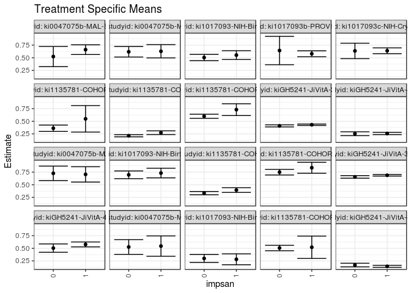

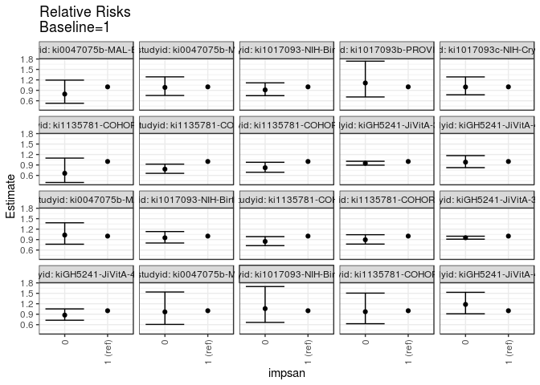

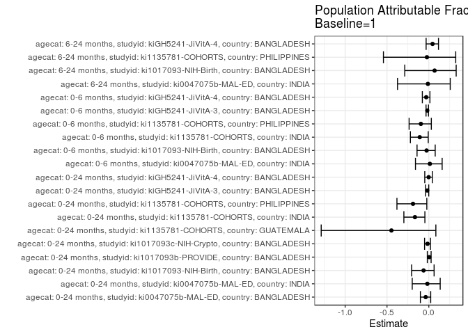

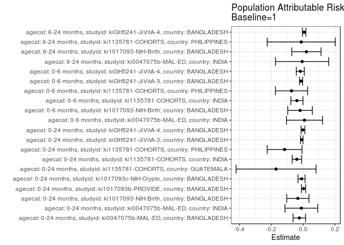

## Results Table

### Parameter: TSM

| agecat | studyid | country | intervention_level | baseline_level | estimate | ci_lower | ci_upper |
| --- | --- | --- | --- | --- | --- | --- | --- |
| 0-24 months | ki0047075b-MAL-ED | BANGLADESH | 1 | NA | 0.6600665 | 0.5639939 | 0.7561392 |
| 0-24 months | ki0047075b-MAL-ED | BANGLADESH | 0 | NA | 0.5237067 | 0.3247112 | 0.7227022 |
| 0-24 months | ki0047075b-MAL-ED | INDIA | 1 | NA | 0.6284529 | 0.4972539 | 0.7596519 |
| 0-24 months | ki0047075b-MAL-ED | INDIA | 0 | NA | 0.6183256 | 0.5142703 | 0.7223808 |
| 0-24 months | ki1017093-NIH-Birth | BANGLADESH | 1 | NA | 0.5528524 | 0.4658284 | 0.6398763 |
| 0-24 months | ki1017093-NIH-Birth | BANGLADESH | 0 | NA | 0.5045188 | 0.4421240 | 0.5669136 |
| 0-24 months | ki1017093b-PROVIDE | BANGLADESH | 1 | NA | 0.5787671 | 0.5206376 | 0.6368967 |
| 0-24 months | ki1017093b-PROVIDE | BANGLADESH | 0 | NA | 0.6428571 | 0.3621822 | 0.9235321 |
| 0-24 months | ki1017093c-NIH-Crypto | BANGLADESH | 1 | NA | 0.6380678 | 0.5806544 | 0.6954812 |
| 0-24 months | ki1017093c-NIH-Crypto | BANGLADESH | 0 | NA | 0.6353095 | 0.4828729 | 0.7877460 |
| 0-24 months | ki1135781-COHORTS | GUATEMALA | 1 | NA | 0.5481140 | 0.2863480 | 0.8098800 |
| 0-24 months | ki1135781-COHORTS | GUATEMALA | 0 | NA | 0.3620681 | 0.2990802 | 0.4250559 |
| 0-24 months | ki1135781-COHORTS | INDIA | 1 | NA | 0.2733187 | 0.2363269 | 0.3103105 |
| 0-24 months | ki1135781-COHORTS | INDIA | 0 | NA | 0.2133252 | 0.1917028 | 0.2349475 |
| 0-24 months | ki1135781-COHORTS | PHILIPPINES | 1 | NA | 0.7294482 | 0.6130663 | 0.8458302 |
| 0-24 months | ki1135781-COHORTS | PHILIPPINES | 0 | NA | 0.5988517 | 0.5583685 | 0.6393349 |
| 0-24 months | kiGH5241-JiVitA-3 | BANGLADESH | 1 | NA | 0.4308865 | 0.4170034 | 0.4447695 |
| 0-24 months | kiGH5241-JiVitA-3 | BANGLADESH | 0 | NA | 0.4087291 | 0.3884670 | 0.4289912 |
| 0-24 months | kiGH5241-JiVitA-4 | BANGLADESH | 1 | NA | 0.2585165 | 0.2355674 | 0.2814656 |
| 0-24 months | kiGH5241-JiVitA-4 | BANGLADESH | 0 | NA | 0.2535726 | 0.2152878 | 0.2918574 |
| 0-6 months | ki0047075b-MAL-ED | INDIA | 1 | NA | 0.7051816 | 0.5533238 | 0.8570395 |
| 0-6 months | ki0047075b-MAL-ED | INDIA | 0 | NA | 0.7263654 | 0.5831900 | 0.8695408 |
| 0-6 months | ki1017093-NIH-Birth | BANGLADESH | 1 | NA | 0.7318984 | 0.6363163 | 0.8274804 |
| 0-6 months | ki1017093-NIH-Birth | BANGLADESH | 0 | NA | 0.6967845 | 0.6204239 | 0.7731452 |
| 0-6 months | ki1135781-COHORTS | INDIA | 1 | NA | 0.3952610 | 0.3486442 | 0.4418779 |
| 0-6 months | ki1135781-COHORTS | INDIA | 0 | NA | 0.3345402 | 0.3024001 | 0.3666803 |
| 0-6 months | ki1135781-COHORTS | PHILIPPINES | 1 | NA | 0.8367347 | 0.7280039 | 0.9454655 |
| 0-6 months | ki1135781-COHORTS | PHILIPPINES | 0 | NA | 0.7489177 | 0.6935154 | 0.8043201 |
| 0-6 months | kiGH5241-JiVitA-3 | BANGLADESH | 1 | NA | 0.6881323 | 0.6717723 | 0.7044922 |
| 0-6 months | kiGH5241-JiVitA-3 | BANGLADESH | 0 | NA | 0.6557057 | 0.6307198 | 0.6806917 |
| 0-6 months | kiGH5241-JiVitA-4 | BANGLADESH | 1 | NA | 0.5757195 | 0.5272597 | 0.6241794 |
| 0-6 months | kiGH5241-JiVitA-4 | BANGLADESH | 0 | NA | 0.5034786 | 0.4208627 | 0.5860944 |
| 6-24 months | ki0047075b-MAL-ED | INDIA | 1 | NA | 0.5435187 | 0.3429363 | 0.7441010 |
| 6-24 months | ki0047075b-MAL-ED | INDIA | 0 | NA | 0.5253962 | 0.3799089 | 0.6708835 |
| 6-24 months | ki1017093-NIH-Birth | BANGLADESH | 1 | NA | 0.2820800 | 0.1742448 | 0.3899153 |
| 6-24 months | ki1017093-NIH-Birth | BANGLADESH | 0 | NA | 0.2992425 | 0.2200167 | 0.3784683 |
| 6-24 months | ki1135781-COHORTS | PHILIPPINES | 1 | NA | 0.5201968 | 0.2993589 | 0.7410347 |
| 6-24 months | ki1135781-COHORTS | PHILIPPINES | 0 | NA | 0.5054156 | 0.4515450 | 0.5592863 |
| 6-24 months | kiGH5241-JiVitA-4 | BANGLADESH | 1 | NA | 0.1426200 | 0.1219316 | 0.1633085 |
| 6-24 months | kiGH5241-JiVitA-4 | BANGLADESH | 0 | NA | 0.1683319 | 0.1322540 | 0.2044098 |

### Parameter: E(Y)

| agecat | studyid | country | intervention_level | baseline_level | estimate | ci_lower | ci_upper |
| --- | --- | --- | --- | --- | --- | --- | --- |
| 0-24 months | ki0047075b-MAL-ED | BANGLADESH | NA | NA | 0.6363636 | 0.5494154 | 0.7233119 |
| 0-24 months | ki0047075b-MAL-ED | INDIA | NA | NA | 0.6176471 | 0.5365376 | 0.6987565 |
| 0-24 months | ki1017093-NIH-Birth | BANGLADESH | NA | NA | 0.5201900 | 0.4695846 | 0.5707955 |
| 0-24 months | ki1017093b-PROVIDE | BANGLADESH | NA | NA | 0.5816993 | 0.5247676 | 0.6386311 |
| 0-24 months | ki1017093c-NIH-Crypto | BANGLADESH | NA | NA | 0.6286645 | 0.5746609 | 0.6826681 |
| 0-24 months | ki1135781-COHORTS | GUATEMALA | NA | NA | 0.3787879 | 0.3179432 | 0.4396325 |
| 0-24 months | ki1135781-COHORTS | INDIA | NA | NA | 0.2344546 | 0.2156201 | 0.2532892 |
| 0-24 months | ki1135781-COHORTS | PHILIPPINES | NA | NA | 0.6134700 | 0.5751620 | 0.6517779 |
| 0-24 months | kiGH5241-JiVitA-3 | BANGLADESH | NA | NA | 0.4226600 | 0.4115317 | 0.4337883 |
| 0-24 months | kiGH5241-JiVitA-4 | BANGLADESH | NA | NA | 0.2580019 | 0.2386523 | 0.2773515 |
| 0-6 months | ki0047075b-MAL-ED | INDIA | NA | NA | 0.7142857 | 0.6098683 | 0.8187031 |
| 0-6 months | ki1017093-NIH-Birth | BANGLADESH | NA | NA | 0.7130045 | 0.6535890 | 0.7724200 |
| 0-6 months | ki1135781-COHORTS | INDIA | NA | NA | 0.3565891 | 0.3304405 | 0.3827378 |
| 0-6 months | ki1135781-COHORTS | PHILIPPINES | NA | NA | 0.7642857 | 0.7146210 | 0.8139505 |
| 0-6 months | kiGH5241-JiVitA-3 | BANGLADESH | NA | NA | 0.6756128 | 0.6622741 | 0.6889516 |
| 0-6 months | kiGH5241-JiVitA-4 | BANGLADESH | NA | NA | 0.5583942 | 0.5167799 | 0.6000084 |
| 6-24 months | ki0047075b-MAL-ED | INDIA | NA | NA | 0.5376344 | 0.4216441 | 0.6536247 |
| 6-24 months | ki1017093-NIH-Birth | BANGLADESH | NA | NA | 0.3030303 | 0.2377927 | 0.3682679 |
| 6-24 months | ki1135781-COHORTS | PHILIPPINES | NA | NA | 0.5086849 | 0.4571562 | 0.5602135 |
| 6-24 months | kiGH5241-JiVitA-4 | BANGLADESH | NA | NA | 0.1492734 | 0.1316631 | 0.1668838 |

### Parameter: RR

| agecat | studyid | country | intervention_level | baseline_level | estimate | ci_lower | ci_upper |
| --- | --- | --- | --- | --- | --- | --- | --- |
| 0-24 months | ki0047075b-MAL-ED | BANGLADESH | 1 | 1 | 1.0000000 | 1.0000000 | 1.0000000 |
| 0-24 months | ki0047075b-MAL-ED | BANGLADESH | 0 | 1 | 0.7934151 | 0.5278071 | 1.1926848 |
| 0-24 months | ki0047075b-MAL-ED | INDIA | 1 | 1 | 1.0000000 | 1.0000000 | 1.0000000 |
| 0-24 months | ki0047075b-MAL-ED | INDIA | 0 | 1 | 0.9838853 | 0.7520650 | 1.2871631 |
| 0-24 months | ki1017093-NIH-Birth | BANGLADESH | 1 | 1 | 1.0000000 | 1.0000000 | 1.0000000 |
| 0-24 months | ki1017093-NIH-Birth | BANGLADESH | 0 | 1 | 0.9125742 | 0.7468489 | 1.1150738 |
| 0-24 months | ki1017093b-PROVIDE | BANGLADESH | 1 | 1 | 1.0000000 | 1.0000000 | 1.0000000 |
| 0-24 months | ki1017093b-PROVIDE | BANGLADESH | 0 | 1 | 1.1107354 | 0.7096843 | 1.7384254 |
| 0-24 months | ki1017093c-NIH-Crypto | BANGLADESH | 1 | 1 | 1.0000000 | 1.0000000 | 1.0000000 |
| 0-24 months | ki1017093c-NIH-Crypto | BANGLADESH | 0 | 1 | 0.9956770 | 0.7716346 | 1.2847696 |
| 0-24 months | ki1135781-COHORTS | GUATEMALA | 1 | 1 | 1.0000000 | 1.0000000 | 1.0000000 |
| 0-24 months | ki1135781-COHORTS | GUATEMALA | 0 | 1 | 0.6605707 | 0.3975669 | 1.0975605 |
| 0-24 months | ki1135781-COHORTS | INDIA | 1 | 1 | 1.0000000 | 1.0000000 | 1.0000000 |
| 0-24 months | ki1135781-COHORTS | INDIA | 0 | 1 | 0.7804997 | 0.6591797 | 0.9241482 |
| 0-24 months | ki1135781-COHORTS | PHILIPPINES | 1 | 1 | 1.0000000 | 1.0000000 | 1.0000000 |
| 0-24 months | ki1135781-COHORTS | PHILIPPINES | 0 | 1 | 0.8209653 | 0.6902134 | 0.9764864 |
| 0-24 months | kiGH5241-JiVitA-3 | BANGLADESH | 1 | 1 | 1.0000000 | 1.0000000 | 1.0000000 |
| 0-24 months | kiGH5241-JiVitA-3 | BANGLADESH | 0 | 1 | 0.9485772 | 0.8945203 | 1.0059007 |
| 0-24 months | kiGH5241-JiVitA-4 | BANGLADESH | 1 | 1 | 1.0000000 | 1.0000000 | 1.0000000 |
| 0-24 months | kiGH5241-JiVitA-4 | BANGLADESH | 0 | 1 | 0.9808758 | 0.8231987 | 1.1687547 |
| 0-6 months | ki0047075b-MAL-ED | INDIA | 1 | 1 | 1.0000000 | 1.0000000 | 1.0000000 |
| 0-6 months | ki0047075b-MAL-ED | INDIA | 0 | 1 | 1.0300402 | 0.7674567 | 1.3824658 |
| 0-6 months | ki1017093-NIH-Birth | BANGLADESH | 1 | 1 | 1.0000000 | 1.0000000 | 1.0000000 |
| 0-6 months | ki1017093-NIH-Birth | BANGLADESH | 0 | 1 | 0.9520236 | 0.8020259 | 1.1300744 |
| 0-6 months | ki1135781-COHORTS | INDIA | 1 | 1 | 1.0000000 | 1.0000000 | 1.0000000 |
| 0-6 months | ki1135781-COHORTS | INDIA | 0 | 1 | 0.8463778 | 0.7270824 | 0.9852465 |
| 0-6 months | ki1135781-COHORTS | PHILIPPINES | 1 | 1 | 1.0000000 | 1.0000000 | 1.0000000 |
| 0-6 months | ki1135781-COHORTS | PHILIPPINES | 0 | 1 | 0.8950480 | 0.7707387 | 1.0394068 |
| 0-6 months | kiGH5241-JiVitA-3 | BANGLADESH | 1 | 1 | 1.0000000 | 1.0000000 | 1.0000000 |
| 0-6 months | kiGH5241-JiVitA-3 | BANGLADESH | 0 | 1 | 0.9528775 | 0.9113687 | 0.9962768 |
| 0-6 months | kiGH5241-JiVitA-4 | BANGLADESH | 1 | 1 | 1.0000000 | 1.0000000 | 1.0000000 |
| 0-6 months | kiGH5241-JiVitA-4 | BANGLADESH | 0 | 1 | 0.8745206 | 0.7270209 | 1.0519452 |
| 6-24 months | ki0047075b-MAL-ED | INDIA | 1 | 1 | 1.0000000 | 1.0000000 | 1.0000000 |
| 6-24 months | ki0047075b-MAL-ED | INDIA | 0 | 1 | 0.9666571 | 0.6076948 | 1.5376567 |
| 6-24 months | ki1017093-NIH-Birth | BANGLADESH | 1 | 1 | 1.0000000 | 1.0000000 | 1.0000000 |
| 6-24 months | ki1017093-NIH-Birth | BANGLADESH | 0 | 1 | 1.0608424 | 0.6642052 | 1.6943357 |
| 6-24 months | ki1135781-COHORTS | PHILIPPINES | 1 | 1 | 1.0000000 | 1.0000000 | 1.0000000 |
| 6-24 months | ki1135781-COHORTS | PHILIPPINES | 0 | 1 | 0.9715853 | 0.6270876 | 1.5053369 |
| 6-24 months | kiGH5241-JiVitA-4 | BANGLADESH | 1 | 1 | 1.0000000 | 1.0000000 | 1.0000000 |
| 6-24 months | kiGH5241-JiVitA-4 | BANGLADESH | 0 | 1 | 1.1802825 | 0.9110854 | 1.5290188 |

### Parameter: PAR

| agecat | studyid | country | intervention_level | baseline_level | estimate | ci_lower | ci_upper |
| --- | --- | --- | --- | --- | --- | --- | --- |
| 0-24 months | ki0047075b-MAL-ED | BANGLADESH | 1 | NA | -0.0237029 | -0.0628011 | 0.0153954 |
| 0-24 months | ki0047075b-MAL-ED | INDIA | 1 | NA | -0.0108058 | -0.1135963 | 0.0919847 |
| 0-24 months | ki1017093-NIH-Birth | BANGLADESH | 1 | NA | -0.0326623 | -0.1024371 | 0.0371124 |
| 0-24 months | ki1017093b-PROVIDE | BANGLADESH | 1 | NA | 0.0029322 | -0.0102359 | 0.0161003 |
| 0-24 months | ki1017093c-NIH-Crypto | BANGLADESH | 1 | NA | -0.0094033 | -0.0314253 | 0.0126187 |
| 0-24 months | ki1135781-COHORTS | GUATEMALA | 1 | NA | -0.1693262 | -0.4202679 | 0.0816156 |
| 0-24 months | ki1135781-COHORTS | INDIA | 1 | NA | -0.0388641 | -0.0684799 | -0.0092483 |
| 0-24 months | ki1135781-COHORTS | PHILIPPINES | 1 | NA | -0.1159783 | -0.2250743 | -0.0068823 |
| 0-24 months | kiGH5241-JiVitA-3 | BANGLADESH | 1 | NA | -0.0082265 | -0.0161614 | -0.0002916 |
| 0-24 months | kiGH5241-JiVitA-4 | BANGLADESH | 1 | NA | -0.0005146 | -0.0121991 | 0.0111700 |
| 0-6 months | ki0047075b-MAL-ED | INDIA | 1 | NA | 0.0091041 | -0.1043447 | 0.1225529 |
| 0-6 months | ki1017093-NIH-Birth | BANGLADESH | 1 | NA | -0.0188939 | -0.0960947 | 0.0583069 |
| 0-6 months | ki1135781-COHORTS | INDIA | 1 | NA | -0.0386719 | -0.0765903 | -0.0007535 |
| 0-6 months | ki1135781-COHORTS | PHILIPPINES | 1 | NA | -0.0724490 | -0.1732018 | 0.0283039 |
| 0-6 months | kiGH5241-JiVitA-3 | BANGLADESH | 1 | NA | -0.0125194 | -0.0223338 | -0.0027051 |
| 0-6 months | kiGH5241-JiVitA-4 | BANGLADESH | 1 | NA | -0.0173254 | -0.0425697 | 0.0079190 |
| 6-24 months | ki0047075b-MAL-ED | INDIA | 1 | NA | -0.0058843 | -0.1725790 | 0.1608105 |
| 6-24 months | ki1017093-NIH-Birth | BANGLADESH | 1 | NA | 0.0209503 | -0.0708441 | 0.1127446 |
| 6-24 months | ki1135781-COHORTS | PHILIPPINES | 1 | NA | -0.0115120 | -0.2253273 | 0.2023033 |
| 6-24 months | kiGH5241-JiVitA-4 | BANGLADESH | 1 | NA | 0.0066534 | -0.0043511 | 0.0176580 |

### Parameter: PAF

| agecat | studyid | country | intervention_level | baseline_level | estimate | ci_lower | ci_upper |
| --- | --- | --- | --- | --- | --- | --- | --- |
| 0-24 months | ki0047075b-MAL-ED | BANGLADESH | 1 | NA | -0.0372474 | -0.1006550 | 0.0225074 |
| 0-24 months | ki0047075b-MAL-ED | INDIA | 1 | NA | -0.0174952 | -0.1983090 | 0.1360355 |
| 0-24 months | ki1017093-NIH-Birth | BANGLADESH | 1 | NA | -0.0627892 | -0.2057712 | 0.0632377 |
| 0-24 months | ki1017093b-PROVIDE | BANGLADESH | 1 | NA | 0.0050408 | -0.0178496 | 0.0274163 |
| 0-24 months | ki1017093c-NIH-Crypto | BANGLADESH | 1 | NA | -0.0149576 | -0.0506820 | 0.0195521 |
| 0-24 months | ki1135781-COHORTS | GUATEMALA | 1 | NA | -0.4470211 | -1.2864978 | 0.0842458 |
| 0-24 months | ki1135781-COHORTS | INDIA | 1 | NA | -0.1657637 | -0.2981414 | -0.0468852 |
| 0-24 months | ki1135781-COHORTS | PHILIPPINES | 1 | NA | -0.1890529 | -0.3810415 | -0.0237540 |
| 0-24 months | kiGH5241-JiVitA-3 | BANGLADESH | 1 | NA | -0.0194637 | -0.0384008 | -0.0008719 |
| 0-24 months | kiGH5241-JiVitA-4 | BANGLADESH | 1 | NA | -0.0019944 | -0.0483169 | 0.0422812 |
| 0-6 months | ki0047075b-MAL-ED | INDIA | 1 | NA | 0.0127457 | -0.1595193 | 0.1594180 |
| 0-6 months | ki1017093-NIH-Birth | BANGLADESH | 1 | NA | -0.0264990 | -0.1408107 | 0.0763584 |
| 0-6 months | ki1135781-COHORTS | INDIA | 1 | NA | -0.1084494 | -0.2201531 | -0.0069720 |
| 0-6 months | ki1135781-COHORTS | PHILIPPINES | 1 | NA | -0.0947931 | -0.2355973 | 0.0299657 |
| 0-6 months | kiGH5241-JiVitA-3 | BANGLADESH | 1 | NA | -0.0185305 | -0.0331752 | -0.0040933 |
| 0-6 months | kiGH5241-JiVitA-4 | BANGLADESH | 1 | NA | -0.0310271 | -0.0773273 | 0.0132831 |
| 6-24 months | ki0047075b-MAL-ED | INDIA | 1 | NA | -0.0109447 | -0.3738961 | 0.2561234 |
| 6-24 months | ki1017093-NIH-Birth | BANGLADESH | 1 | NA | 0.0691358 | -0.2875771 | 0.3270243 |
| 6-24 months | ki1135781-COHORTS | PHILIPPINES | 1 | NA | -0.0226309 | -0.5424499 | 0.3220047 |
| 6-24 months | kiGH5241-JiVitA-4 | BANGLADESH | 1 | NA | 0.0445721 | -0.0322228 | 0.1156536 |